Please view https://daswan1118.github.io/Coursera_PML_Project/ for the html documentation

# Practical-Machine-Learning-Course-Project

Devices such as Jawbone Up, Nike FuelBand, and Fitbit enable collection of a large amount of data about personal activity relatively inexpensively. These type of devices are part of the quantified self movement - a group of enthusiasts who take measurements about themselves regularly to improve their health, to find patterns in their behavior, or because they are tech geeks. One thing that people regularly do is quantify how much of a particular activity they do, but they rarely quantify how well they do it. In this project, I used data gathered from accelerometers on the belt, forearm, arm, and dumbell of 6 participants. The goal of the project is to predict the manner (classe) in which people they exercise.

The data for this project come from this source: http://groupware.les.inf.puc-rio.br/har.

### 1. Get Data from CSV & Split Data

Imported data using `read.csv` function.

Split data using caret package’s `createDataPartition` function. Since this is a small dataset with 19622 records, I used 60% for training and 40% for testing.

```r
set.seed(695)
inTrain <- createDataPartition(y=train$classe, p=0.60, list=FALSE)
training <- train[inTrain,]
testing <- train[-inTrain,]
```

### 2. Understand Data & Feature Selection

Used feature plots to understand variables better

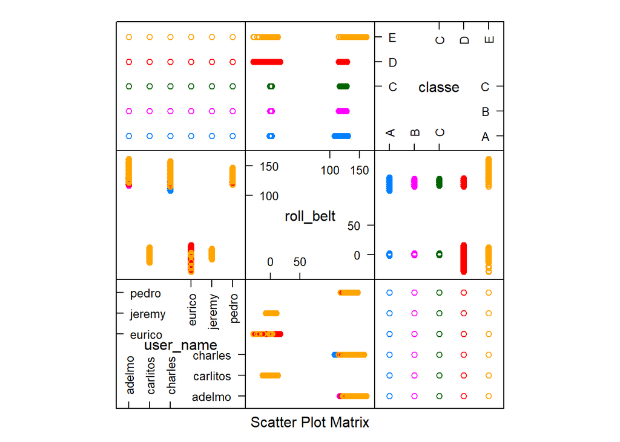

```r
featurePlot(x=training[,c(2,8,160)], y=training$classe, plot="pairs")
```

### 3. Pre-processing

- Convert all categorical to numeric
- Replacing all NAs

### 3. Model Selection

- GLM (Generalized Linear Model)
- Random Forest
- GBM (Gradiant Boosting Model)